# **ECE 7420 Design Project**

> Instructor: Dr. Le Yi Wang  
> Name: Yuqi Wang  
> Student ID: HE1173

## Statement

**I have not received, nor have I given, any help and assistance on this project.**

## Sign:

#### Problem 1:

Consider a plant with input $u$ and output $x$ $$\ddot{x}+(2+\cos{x})\dot{x}^3-\sin{x}=u$$

1. Derive a state space model for the system. Note:Please include both the state equation and output equation.
2. Consider the open-loop system $u=0$.
   - Calculate ALL the equilibrium points.
   - Study the stability of (ALL) the equilibrium points of the open-loop system by using the following methods:
     - Intuitive analysis
     - Local linearization
     - Lyapunov functions
   - Perform simulation to verify your conclusions. Please make sure that you cover different cases. Use at least two typical equilibrium points to demonstrate your results.
3. Design a linear feedback $u=-Kx$ to make the origin (0,0) globally asymptotically stable.
   - Design such a controller.
   - Verify stability by theoretical analysis, such as Lyapunov functions and/or Invariant Set Theorem.
   - Perform simulation to demonstrate the stability of the closed-loop system.

**Solution:**

1. Let $$\begin{equation} \left\{ \begin{matrix} x_1=x \\ x_2=\dot{x} \end{matrix} \right. \end{equation}$$ We have
   $$\begin{equation} \left\{ \begin{array}{rCl} \dot{x_1}=&x_2 \\ \dot{x_2}=&\sin{x_1}-(2+\cos{x_1}){x_2}^3+u \end{array} \right. \end{equation}$$ Output equation: $$y=x_1$$
1. When $u=0$, the equilibrium points are $$\begin{equation} \left\{ \begin{array}{rCl} x_1&=& k\pi \\ x_2&=& 0 \end{array} \right. \end{equation} $$
   - Intuitive analysis
     For small $x$, the linearized approximation about $x=0$ is $$\begin{equation} \left\{ \begin{array}{rCl} \dot{x_1}=&x_2 \\ \dot{x_2}=&x_1 \end{array} \right. \end{equation}$$ The eigenvalue of $$\begin{equation} J= \begin{bmatrix} 0 & 1 \\ 1 & 0 \end{bmatrix} \end{equation}$$ is $\pm 1$, the linearized approximation system is unstable.
   - Local Linearization
     $$ \begin{equation} J= \begin{bmatrix}{} \frac{\partial{f_1}}{x_1} & \frac{\partial{f_1}}{x_2} \\ \frac{\partial{f_2}}{x_1} & \frac{\partial{f_2}}{x_2} \end{bmatrix} {=} \begin{bmatrix}{} 0 & 1 \\ \cos{x_1}+x_2^2\sin{x_1} & -3(2+\cos{x_1})x_2^2 \end{bmatrix} \end{equation}$$ Liearized at equilbrum point: $$ \begin{equation} \begin{bmatrix} \Delta{\dot{x_1}} \\ \Delta{\dot{x_2}} \end{bmatrix} {=} J_{\mid{x_1 = k\pi,x_2 = 0}} \begin{bmatrix} x_1-k\pi \\ x_2-0 \end{bmatrix} {=} \begin{bmatrix} 0 & 1 \\ -1 & 0 \end{bmatrix} \begin{bmatrix} x_1 \\ x_2 \end{bmatrix} + \begin{bmatrix} -k\pi \\ 0 \end{bmatrix} \end{equation} $$ The eigenvalue of $$\begin{equation} J= \begin{bmatrix} 0 & 1 \\ -1 & 0 \end{bmatrix} \end{equation}$$ is $\pm j$, the linearized approximation system is centre. At least one limit cycle can be predicted from the linearized system.
   - Lyapunov Functions
     Chose the Lyapunov function: $$V=\frac{1}{2}x_2^2+1+\cos{x_1} $$
     Due to $1+\cos{x_1} \geq 0$, the Lyapunov function is locally positive definite for system at $(0,0)$. For $\dot{V}$ $$ \begin{equation} \begin{array}{rCl} \dot{V}&=&\dot{x_2}x_2-x_2 \sin{x_1} \\ &=& -(2+\cos{x_1})x_2^4 \leq 0 \end{array} \end{equation}$$ The equilibrium point $(0,0)$ is Lyapunov stable.
1. If $u=-Kx$, the closed-loop system turns to be:
   $$\begin{equation} \left\{ \begin{array}{rCl} \dot{x_1}=&x_2 \\ \dot{x_2}=&\sin{x_1}-(2+\cos{x_1}){x_2}^3-Kx_1 \end{array} \right. \end{equation}$$ According to Lyapunov analysis in 3, chose the Lyapunov function: $$V=\frac{1}{2}x_2^2+ \int_0^{x_1} (Ky-\sin{y})dy $$
   $$ \begin{equation} \begin{array}{rCl} \dot{V}&=&\dot{x_2}x_2+x_2(Kx_1- \sin{x_1}) \\ &=& -(2+\cos{x_1})x_2^4 \leq 0 \end{array} \end{equation}$$ The closed-loop system is globally asymptotically stable at origin, only if the Lyapunov function $V$ is a strict radially unbounded Lyapunov function.
   Due to $x>\sin{x}$, when $K \geq 1$, the Lyapunov function is strict radially unbounded. The system is globally asymptotically stable at origin.

#### Problem 2:

$$G(s)=\frac{1}{s^3+3s^2+3s+1}$$

For each of the following cases, study the following issues: 1) Predict if There is a limit cycle; 2) Calculate the approximate magnitude and frequency of the limit cycle when it is predicted; 3) Study the stability of the limit cycle; 4) Perform simulation to demonstrate your conclusions.  
Note: You may use a non-zero initial condition in the linear system to start your simulation.

- Case1: The nonlinearity is a relay.
- Case2: The nonlinearity is a saturation.
- Case3: The nonlinearity is a dead zone.

**Solution:**
According to the open-loop system: $$G(s)=\frac{1}{s^3+3s^2+3s+1}=\frac{1}{(s+1)^3}$$
$G(s)$ has a 3-order pole which is $s=-1$, the open-loop system is a stable linear system.
Let $s=j\omega$, we have $$G(j\omega) = \frac{1}{-3\omega^2+1-j(\omega^3-3\omega)}$$ From $Im[G(j\omega)]=0$, we have the intersection point between $G(j\omega)$ and the real axis is $G(j1)=-0.125+j0$. Draw the Nyquist Plot of $G(j\omega)$:

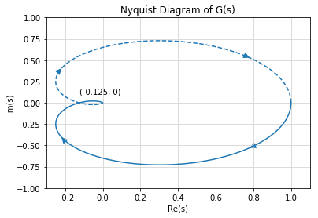

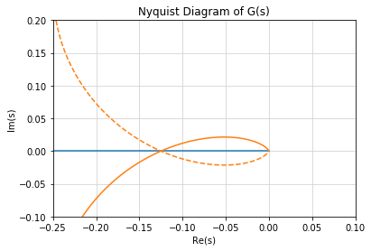

#### Problem 3:

Consider a nonlinear system $$\ddot{x}=-x+x^2\dot{x}+\Delta(x,\dot{x})+bu$$
where $10 \leq b \leq 40 $, $|\Delta(x,\dot{x})| \leq 0.1(x^2 + \dot{x}^4)$.

1) Sliding Mode Control:

```
- Design a robust sliding mode controller with the sliding surface $s=\dot{x}+2x$.
- Perform simulation to demonstrate the behavior of the closed-loop system in the phase plane. This will typically show some chattering.
```

2) Modified Sliding Mode Control:

```
- Modify the sliding mode control by replacing the switching function by a saturation function.
- Perform simulation to demonstrate the behavior of the closed-loop system in the phase plane. This can often eliminate chattering.
```

**Solution:**
Gain uncertainty term: $$\beta = \sqrt{\frac{b_{max}}{b_{min}}}=2$$ $$0<\frac{1}{2} \leq \alpha \leq 2 $$ $$\hat{b}=\sqrt{b_{min}\times b_{max}} = 20$$

1. Define sliding surface : $$s(t)=\dot{x}(t)+2x(t)$$ $$\dot{s} =\ddot{s}+2\dot{s} = -x+x^2\dot{x}+2\dot{x}+\Delta+20\alpha u$$ Design:
   $$ k(x,\dot{x}) = 2\left[-0.1(x^2+\dot{x}^4)+\eta \right] + 2\left| -x+x^2\dot{x}+2\dot{x} \right|$$ $$\begin{equation} \begin{array}{rCL} 20u &=& -k(x,\dot{x}) \text{sign}(s) +x-x^2\dot{x}-2\dot{x} \\ &=& -k(x,\dot{x}) \text{sign}(\dot{x}+2x) +x-x^2\dot{x}-2\dot{x} \end{array} \end{equation} $$
2. Modified Design
   $$ k(x,\dot{x}) = 2\left[-0.1(x^2+\dot{x}^4)+\eta \right] + 2\left| -x+x^2\dot{x}+2\dot{x} \right|$$ $$\begin{equation} \begin{array}{rCL} 20u &=& -k(x,\dot{x}) \text{sat}(s) +x-x^2\dot{x}-2\dot{x} \\ &=& -k(x,\dot{x}) \text{sat}(\dot{x}+2x) +x-x^2\dot{x}-2\dot{x} \end{array} \end{equation} $$

Check: $$V(s)=\frac{1}{2}s^2$$ $$\begin{equation} \begin{array}{rCl} \dot{V} &=& sv+s\Delta \\ &=& -5|s|-0.25\dot{x}^2|s| +s\Delta \\ &\leq & -5|s| \\ &<& 0 \end{array} \end{equation} $$ When $s\neq 0$

State equation: $$\begin{equation} \left\{ \begin{array}{rCl} \dot{x_1}&=&x_2 \\ \dot{x_2}&=& -x_1 + x_1^2 x_2 +\Delta +\alpha 20u \\ &=&f+\Delta +\alpha 20u \end{array} \right. \end{equation} $$

$$\begin{equation} \left\{ \begin{array}{rCl} s &=& x_2+2x_1\\ k(x_1,x_2) &=& 2\left[-0.1(x_1^2+x_2^4)+\eta \right] + 2\left| -x_1+x_1^2x_2+2x_2 \right| \\ 20u&=& -k(x_1,x_2) \text{sign}(s) +x_1-x_1^2x_2-2x_2 \\ f&=& -x_1 + x_1^2 x_2 \\ \Delta &\leq& 0.1(x_1^2+x_2^4) \end{array} \right. \end{equation} $$

**Simulation result**

1. Using $sign(s)$  
   The initial value of the output signal is -$5$. Figure3-1 shows the waveform for output $x_1$, state variable $x_2$, control law $u$ and sliding surface $s$. As we can see from the figure, the output signal reachs $0$ while the sliding surface $s$ is still charttering.

[figure not shown]

   Figure3-1. output $x_1$, state variable $x_2$, control law $u$, sliding surface $s$

Figure3-2 shows the waveform on the phase plane. Figure3-3 is the enlarged waveform for the sliding surface. We can see clearly chattering from the both figures.

[figure not shown]

Figure3-2. chattering in the phase plane

[figure not shown]

Figure3-3. chattering on the sliding surface

1. Using $sat(s)$  
   The initial value of the output signal remain the same as before. Figure3-4 shows the waveform for output $x_1$, state variable $x_2$, control law $u$ and sliding surface $s$. As we can see from the figure, the output signal reachs $0$ but there is no chattering on the sliding surface.

[figure not shown]

   Figure3-4. output $x_1$, state variable $x_2$, control law $u$, sliding surface $s$

Figure3-5 shows the waveform on the phase plane. Figure3-6 is the enlarged waveform for the sliding surface. Both figure show that the chattering has been eliminated by using $sat(s)$ instead of $sign(s)$. But the system is less robustly.

[figure not shown]

Figure3-5. chattering in the phase plane

[figure not shown]

Figure3-6. signal on the sliding surface